# R Notebook

Question A

```r
hkre.data <- read.csv("HKRE.csv")
cor(hkre.data,hkre.data$price)
```

```
            [,1]
ID     0.3290607
price  1.0000000
area   0.8276062
beds   0.2538487
baths  0.5609293
cars   0.5485039
age   -0.3913288
floor  0.1299963
view   0.2064362
```

- area has the greatest correlation with price => 0.8276062
- floor has the weakest correlation with price => 0.1299963

Question 2

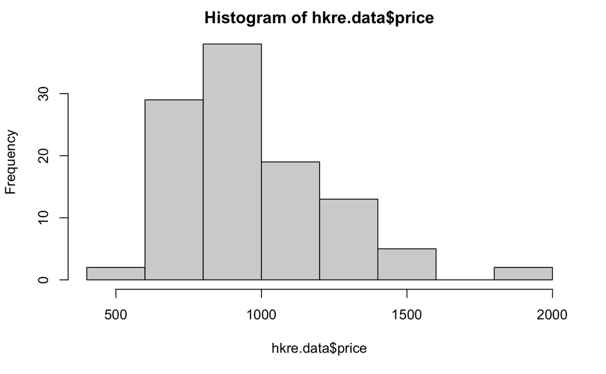

```r
hist(hkre.data$price)
```

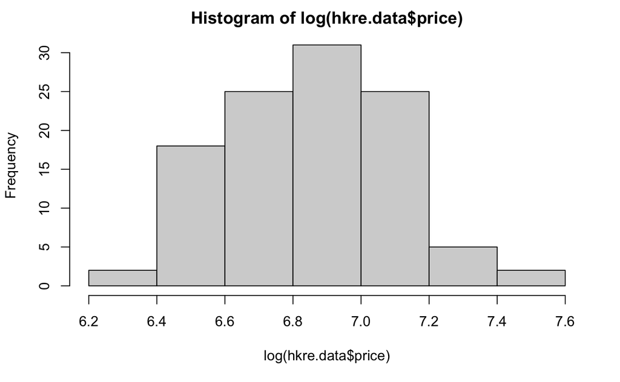

```r
hist(log(hkre.data$price))
```

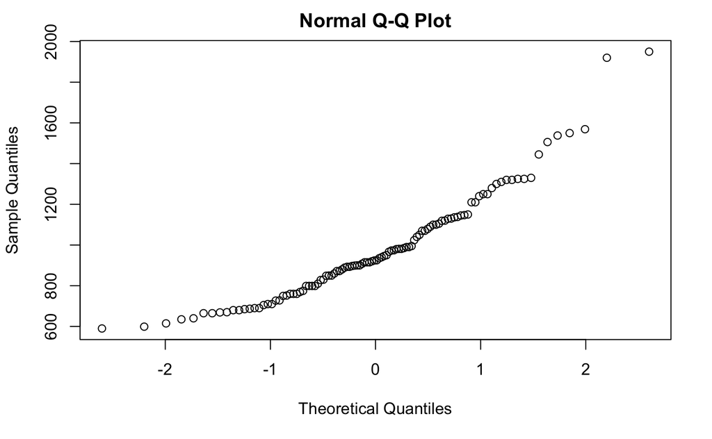

```r
qqnorm(hkre.data$price)
```

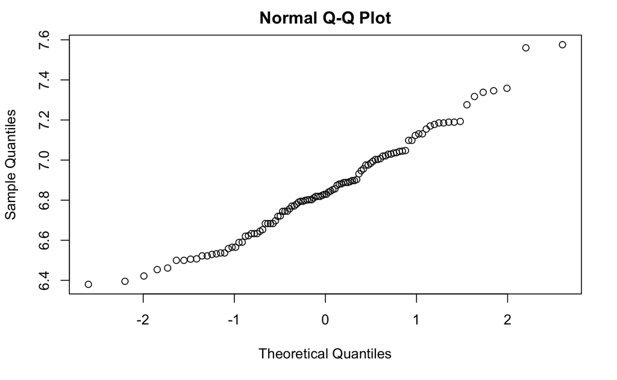

```r
qqnorm(log(hkre.data$price))
```

Yes we should perform log transformation on the price

Question C (a)

I will including everything except id because it is not relevant to the price.

```r
hkre.data$view <- factor(hkre.data$view)
fit1 <- lm(log(price) ~. -ID, data = hkre.data)
summary(fit1)
```

```
Call:
lm(formula = log(price) ~ . - ID, data = hkre.data)

Residuals:
     Min       1Q   Median       3Q      Max
-0.28457 -0.05856 -0.00213  0.06779  0.22994

Coefficients:
              Estimate Std. Error t value Pr(>|t|)
(Intercept)  6.0328082  0.0620921  97.159  < 2e-16 ***
area         0.0003254  0.0000323  10.074  < 2e-16 ***
beds         0.0323501  0.0179970   1.798  0.07530 .
baths        0.0528778  0.0247379   2.138  0.03502 *
cars         0.1773474  0.0345127   5.139 1.39e-06 ***
age         -0.0128701  0.0024863  -5.176 1.19e-06 ***
floor        0.0007459  0.0044716   0.167  0.86785
view1        0.0708676  0.0229778   3.084  0.00265 **
view2        0.2046945  0.0396795   5.159 1.28e-06 ***
---
Signif. codes:  0 ‘***’ 0.001 ‘**’ 0.01 ‘*’ 0.05 ‘.’ 0.1 ‘ ’ 1

Residual standard error: 0.1051 on 99 degrees of freedom
Multiple R-squared:  0.8409,    Adjusted R-squared:  0.8281
F-statistic: 65.43 on 8 and 99 DF,  p-value: < 2.2e-16
```

```r
AIC(fit1)
```

```
[1] -169.5981
```

Residual standard error: 0.1051 on 99 degrees of freedom Multiple R-squared: 0.8409, Adjusted R-squared: 0.8281 F-statistic: 65.43 on 8 and 99 DF, p-value: < 2.2e-16

Everything but floor and beds are statistically significant.

Question D

```r
backward_model_fit1 <- step(fit1, direction = "backward")
```

```
Start:  AIC=-478.09
log(price) ~ (ID + area + beds + baths + cars + age + floor +
    view) - ID

        Df Sum of Sq    RSS     AIC
- floor  1   0.00031 1.0931 -480.06
<none>               1.0928 -478.09
- beds   1   0.03567 1.1284 -476.62
- baths  1   0.05043 1.1432 -475.22
- cars   1   0.29146 1.3842 -454.55
- age    1   0.29577 1.3885 -454.22
- view   2   0.33474 1.4275 -453.23
- area   1   1.12025 2.2130 -403.88

Step:  AIC=-480.06
log(price) ~ area + beds + baths + cars + age + view

        Df Sum of Sq    RSS     AIC
<none>               1.0931 -480.06
- beds   1   0.03953 1.1326 -478.22
- baths  1   0.05013 1.1432 -477.22
- age    1   0.29555 1.3886 -456.21
- cars   1   0.29813 1.3912 -456.01
- view   2   0.37606 1.4691 -452.13
- area   1   1.11997 2.2130 -405.88
```

```r
summary(backward_model_fit1)
```

```
Call:
lm(formula = log(price) ~ area + beds + baths + cars + age +
    view, data = hkre.data)

Residuals:
      Min        1Q    Median        3Q       Max
-0.287366 -0.058837 -0.002358  0.067262  0.231696

Coefficients:
              Estimate Std. Error t value Pr(>|t|)
(Intercept)  6.035e+00  6.063e-02  99.540  < 2e-16 ***
area         3.253e-04  3.214e-05  10.122  < 2e-16 ***
beds         3.307e-02  1.739e-02   1.902  0.06008 .
baths        5.261e-02  2.456e-02   2.142  0.03465 *
cars         1.780e-01  3.409e-02   5.222 9.64e-07 ***
age         -1.286e-02  2.474e-03  -5.200 1.06e-06 ***
view1        7.139e-02  2.265e-02   3.152  0.00214 **
view2        2.067e-01  3.766e-02   5.488 3.08e-07 ***
---
Signif. codes:  0 ‘***’ 0.001 ‘**’ 0.01 ‘*’ 0.05 ‘.’ 0.1 ‘ ’ 1

Residual standard error: 0.1046 on 100 degrees of freedom
Multiple R-squared:  0.8409,    Adjusted R-squared:  0.8298
F-statistic: 75.51 on 7 and 100 DF,  p-value: < 2.2e-16
```

Everything but floor are included in this model.

Question D (b)

Log-tranformation of all

```r
fit2_full <- lm(log(price) ~ log(area) + log(I(beds+1)) + log(I(baths+1)) + log(I(cars+1)) + log(I(age+1)) + log(I(floor)) + view, data = hkre.data )
backward_fit2 <- step(fit2_full, direction = "backward")
```

```
Start:  AIC=-458.52
log(price) ~ log(area) + log(I(beds + 1)) + log(I(baths + 1)) +
    log(I(cars + 1)) + log(I(age + 1)) + log(I(floor)) + view

                    Df Sum of Sq    RSS     AIC
- log(I(floor))      1   0.00501 1.3149 -460.11
<none>                           1.3099 -458.52
- log(I(baths + 1))  1   0.05853 1.3684 -455.80
- log(I(beds + 1))   1   0.07188 1.3818 -454.75
- log(I(cars + 1))   1   0.23621 1.5461 -442.61
- view               2   0.31643 1.6263 -439.15
- log(I(age + 1))    1   0.44395 1.7538 -429.00
- log(area)          1   0.97147 2.2814 -400.60

Step:  AIC=-460.11
log(price) ~ log(area) + log(I(beds + 1)) + log(I(baths + 1)) +
    log(I(cars + 1)) + log(I(age + 1)) + view

                    Df Sum of Sq    RSS     AIC
<none>                           1.3149 -460.11
- log(I(baths + 1))  1   0.05644 1.3713 -457.57
- log(I(beds + 1))   1   0.08885 1.4037 -455.04
- log(I(cars + 1))   1   0.24859 1.5635 -443.40
- view               2   0.36851 1.6834 -437.42
- log(I(age + 1))    1   0.44534 1.7602 -430.60
- log(area)          1   0.96838 2.2833 -402.50
```

```r
summary(backward_fit2)
```

```
Call:
lm(formula = log(price) ~ log(area) + log(I(beds + 1)) + log(I(baths +
    1)) + log(I(cars + 1)) + log(I(age + 1)) + view, data = hkre.data)

Residuals:
     Min       1Q   Median       3Q      Max
-0.30947 -0.06592 -0.01459  0.07571  0.29677

Coefficients:
                  Estimate Std. Error t value Pr(>|t|)
(Intercept)        3.01125    0.39354   7.652 1.26e-11 ***
log(area)          0.48400    0.05640   8.582 1.25e-13 ***
log(I(beds + 1))   0.18318    0.07047   2.599  0.01075 *
log(I(baths + 1))  0.14735    0.07112   2.072  0.04086 *
log(I(cars + 1))   0.30870    0.07100   4.348 3.31e-05 ***
log(I(age + 1))   -0.15678    0.02694  -5.820 7.14e-08 ***
view1              0.07115    0.02489   2.858  0.00518 **
view2              0.20598    0.04144   4.970 2.77e-06 ***
---
Signif. codes:  0 ‘***’ 0.001 ‘**’ 0.01 ‘*’ 0.05 ‘.’ 0.1 ‘ ’ 1

Residual standard error: 0.1147 on 100 degrees of freedom
Multiple R-squared:  0.8086,    Adjusted R-squared:  0.7952
F-statistic: 60.36 on 7 and 100 DF,  p-value: < 2.2e-16
```

Square terms for all numeric variables

```r
fit3_full <- lm(log(price) ~ I(area^2) + I(beds^2) + I(baths^2) + I(cars^2) + I(age^2) + I(floor^2) + view, data = hkre.data )
backward_fit3 <- stepAIC(fit3_full, direction = "backward")
```

```
Start:  AIC=-481.13
log(price) ~ I(area^2) + I(beds^2) + I(baths^2) + I(cars^2) +
    I(age^2) + I(floor^2) + view

             Df Sum of Sq    RSS     AIC
- I(floor^2)  1   0.00029 1.0627 -483.10
- I(beds^2)   1   0.00320 1.0656 -482.80
<none>                    1.0625 -481.13
- I(baths^2)  1   0.07562 1.1381 -475.70
- I(age^2)    1   0.15590 1.2184 -468.34
- I(cars^2)   1   0.23005 1.2925 -461.96
- view        2   0.32432 1.3868 -456.36
- I(area^2)   1   1.51735 2.5798 -387.32

Step:  AIC=-483.1
log(price) ~ I(area^2) + I(beds^2) + I(baths^2) + I(cars^2) +
    I(age^2) + view

             Df Sum of Sq    RSS     AIC
- I(beds^2)   1   0.00376 1.0665 -484.72
<none>                    1.0627 -483.10
- I(baths^2)  1   0.07536 1.1381 -477.70
- I(age^2)    1   0.15561 1.2184 -470.34
- I(cars^2)   1   0.23414 1.2969 -463.59
- view        2   0.36675 1.4295 -455.08
- I(area^2)   1   1.51708 2.5798 -389.32

Step:  AIC=-484.72
log(price) ~ I(area^2) + I(baths^2) + I(cars^2) + I(age^2) +
    view

             Df Sum of Sq    RSS     AIC
<none>                    1.0665 -484.72
- I(baths^2)  1   0.09780 1.1643 -477.24
- I(age^2)    1   0.15880 1.2253 -471.73
- I(cars^2)   1   0.23107 1.2976 -465.54
- view        2   0.37071 1.4372 -456.50
- I(area^2)   1   1.57834 2.6448 -388.63
```

```r
summary(backward_fit3)
```

```
Call:
lm(formula = log(price) ~ I(area^2) + I(baths^2) + I(cars^2) +
    I(age^2) + view, data = hkre.data)

Residuals:
     Min       1Q   Median       3Q      Max
-0.26078 -0.05817 -0.00696  0.07705  0.23020

Coefficients:
              Estimate Std. Error t value Pr(>|t|)
(Intercept)  6.397e+00  3.160e-02 202.437  < 2e-16 ***
I(area^2)    1.042e-07  8.523e-09  12.226  < 2e-16 ***
I(baths^2)   1.950e-02  6.406e-03   3.043 0.002982 **
I(cars^2)    6.335e-02  1.354e-02   4.678 9.01e-06 ***
I(age^2)    -3.644e-04  9.398e-05  -3.878 0.000188 ***
view1        7.300e-02  2.228e-02   3.276 0.001444 **
view2        2.019e-01  3.690e-02   5.470 3.27e-07 ***
---
Signif. codes:  0 ‘***’ 0.001 ‘**’ 0.01 ‘*’ 0.05 ‘.’ 0.1 ‘ ’ 1

Residual standard error: 0.1028 on 101 degrees of freedom
Multiple R-squared:  0.8448,    Adjusted R-squared:  0.8355
F-statistic: 91.61 on 6 and 101 DF,  p-value: < 2.2e-16
```

```r
AIC(backward_fit3)
```

```
[1] -176.2253
```

```r
extractAIC(backward_fit3)
```

```
[1]    7.000 -484.716
```

polynomials model with more than 2 degree

```r
fit4_full <- lm(log(price) ~ I(area^3) + I(beds^3) + I(baths^3) + I(cars^3) + I(age^3) + I(floor^3) + view, data = hkre.data )
backward_fit4 <- step(fit4_full, direction = "backward")
```

```
Start:  AIC=-474.48
log(price) ~ I(area^3) + I(beds^3) + I(baths^3) + I(cars^3) +
    I(age^3) + I(floor^3) + view

             Df Sum of Sq    RSS     AIC
- I(floor^3)  1   0.00102 1.1309 -476.38
- I(beds^3)   1   0.00118 1.1311 -476.37
<none>                    1.1299 -474.48
- I(age^3)    1   0.10727 1.2372 -466.68
- I(baths^3)  1   0.10965 1.2396 -466.48
- I(cars^3)   1   0.15240 1.2823 -462.81
- view        2   0.33228 1.4622 -450.64
- I(area^3)   1   1.95596 3.0859 -367.97

Step:  AIC=-476.38
log(price) ~ I(area^3) + I(beds^3) + I(baths^3) + I(cars^3) +
    I(age^3) + view

             Df Sum of Sq    RSS     AIC
- I(beds^3)   1   0.00084 1.1318 -478.30
<none>                    1.1309 -476.38
- I(age^3)    1   0.10644 1.2374 -468.67
- I(baths^3)  1   0.10916 1.2401 -468.43
- I(cars^3)   1   0.15626 1.2872 -464.40
- view        2   0.38457 1.5155 -448.77
- I(area^3)   1   1.95575 3.0867 -369.94

Step:  AIC=-478.3
log(price) ~ I(area^3) + I(baths^3) + I(cars^3) + I(age^3) +
    view

             Df Sum of Sq    RSS     AIC
<none>                    1.1318 -478.30
- I(baths^3)  1   0.11871 1.2505 -469.53
- I(age^3)    1   0.12564 1.2574 -468.93
- I(cars^3)   1   0.15892 1.2907 -466.11
- view        2   0.38376 1.5155 -450.77
- I(area^3)   1   1.99563 3.1274 -370.53
```

```r
summary(backward_fit4)
```

```
Call:
lm(formula = log(price) ~ I(area^3) + I(baths^3) + I(cars^3) +
    I(age^3) + view, data = hkre.data)

Residuals:
      Min        1Q    Median        3Q       Max
-0.256991 -0.068902 -0.006143  0.080320  0.219159

Coefficients:
              Estimate Std. Error t value Pr(>|t|)
(Intercept)  6.524e+00  2.386e-02 273.390  < 2e-16 ***
I(area^3)    3.910e-11  2.930e-12  13.345  < 2e-16 ***
I(baths^3)   7.029e-03  2.160e-03   3.255 0.001545 **
I(cars^3)    2.337e-02  6.205e-03   3.766 0.000279 ***
I(age^3)    -1.550e-05  4.629e-06  -3.348 0.001143 **
view1        7.428e-02  2.296e-02   3.235 0.001645 **
view2        2.048e-01  3.803e-02   5.385 4.74e-07 ***
---
Signif. codes:  0 ‘***’ 0.001 ‘**’ 0.01 ‘*’ 0.05 ‘.’ 0.1 ‘ ’ 1

Residual standard error: 0.1059 on 101 degrees of freedom
Multiple R-squared:  0.8353,    Adjusted R-squared:  0.8255
F-statistic: 85.35 on 6 and 101 DF,  p-value: < 2.2e-16
```

polynomials model with more than 2 degree (second one)

```r
fit5_full <- lm(log(price) ~ I(area^4) + I(beds^4) + I(baths^4) + I(cars^4) + I(age^4) + I(floor^4) + view, data = hkre.data )
backward_fit5 <- step(fit5_full, direction = "backward")
```

```
Start:  AIC=-459.45
log(price) ~ I(area^4) + I(beds^4) + I(baths^4) + I(cars^4) +
    I(age^4) + I(floor^4) + view

             Df Sum of Sq    RSS     AIC
- I(floor^4)  1   0.00203 1.3006 -461.29
- I(beds^4)   1   0.00399 1.3025 -461.12
<none>                    1.2986 -459.45
- I(age^4)    1   0.09240 1.3910 -454.03
- I(cars^4)   1   0.10979 1.4084 -452.69
- I(baths^4)  1   0.13583 1.4344 -450.71
- view        2   0.34383 1.6424 -438.09
- I(area^4)   1   2.26442 3.5630 -352.45

Step:  AIC=-461.29
log(price) ~ I(area^4) + I(beds^4) + I(baths^4) + I(cars^4) +
    I(age^4) + view

             Df Sum of Sq    RSS     AIC
- I(beds^4)   1   0.00320 1.3038 -463.02
<none>                    1.3006 -461.29
- I(age^4)    1   0.09128 1.3919 -455.96
- I(cars^4)   1   0.11390 1.4145 -454.22
- I(baths^4)  1   0.13518 1.4358 -452.61
- view        2   0.40583 1.7064 -435.96
- I(area^4)   1   2.26637 3.5670 -354.32

Step:  AIC=-463.02
log(price) ~ I(area^4) + I(baths^4) + I(cars^4) + I(age^4) +
    view

             Df Sum of Sq    RSS     AIC
<none>                    1.3038 -463.02
- I(age^4)    1   0.11141 1.4152 -456.17
- I(cars^4)   1   0.11709 1.4209 -455.73
- I(baths^4)  1   0.14346 1.4473 -453.75
- view        2   0.40307 1.7069 -437.93
- I(area^4)   1   2.29744 3.6012 -355.29
```

```r
summary(backward_fit5)
```

```
Call:
lm(formula = log(price) ~ I(area^4) + I(baths^4) + I(cars^4) +
    I(age^4) + view, data = hkre.data)

Residuals:
      Min        1Q    Median        3Q       Max
-0.295577 -0.075895 -0.002518  0.087117  0.222188

Coefficients:
              Estimate Std. Error t value Pr(>|t|)
(Intercept)  6.592e+00  2.139e-02 308.223  < 2e-16 ***
I(area^4)    1.504e-14  1.127e-15  13.341  < 2e-16 ***
I(baths^4)   2.566e-03  7.696e-04   3.334  0.00120 **
I(cars^4)    9.530e-03  3.164e-03   3.012  0.00328 **
I(age^4)    -7.210e-07  2.454e-07  -2.938  0.00410 **
view1        7.631e-02  2.465e-02   3.096  0.00254 **
view2        2.096e-01  4.089e-02   5.126 1.43e-06 ***
---
Signif. codes:  0 ‘***’ 0.001 ‘**’ 0.01 ‘*’ 0.05 ‘.’ 0.1 ‘ ’ 1

Residual standard error: 0.1136 on 101 degrees of freedom
Multiple R-squared:  0.8102,    Adjusted R-squared:  0.799
F-statistic: 71.87 on 6 and 101 DF,  p-value: < 2.2e-16
```

```r
fit6_full <- lm(log(price) ~. -ID + area*view + area*cars + area*beds, data = hkre.data )
backward_fit6 <- step(fit6_full, direction = "backward")
```

```
Start:  AIC=-473.62
log(price) ~ (ID + area + beds + baths + cars + age + floor +
    view) - ID + area * view + area * cars + area * beds

            Df Sum of Sq    RSS     AIC
- area:view  2  0.008448 1.0661 -476.76
- floor      1  0.000359 1.0580 -475.58
- area:beds  1  0.004482 1.0621 -475.16
<none>                   1.0577 -473.62
- area:cars  1  0.023446 1.0811 -473.25
- baths      1  0.064889 1.1225 -469.19
- age        1  0.228942 1.2866 -454.45

Step:  AIC=-476.76
log(price) ~ area + beds + baths + cars + age + floor + view +
    area:cars + area:beds

            Df Sum of Sq    RSS     AIC
- floor      1   0.00034 1.0664 -478.72
- area:beds  1   0.00606 1.0722 -478.14
<none>                   1.0661 -476.76
- area:cars  1   0.02115 1.0873 -476.64
- baths      1   0.06180 1.1279 -472.67
- age        1   0.22839 1.2945 -457.79
- view       2   0.33134 1.3975 -451.53

Step:  AIC=-478.72
log(price) ~ area + beds + baths + cars + age + view + area:cars +
    area:beds

            Df Sum of Sq    RSS     AIC
- area:beds  1   0.00629 1.0727 -480.09
<none>                   1.0664 -478.72
- area:cars  1   0.02096 1.0874 -478.62
- baths      1   0.06146 1.1279 -474.67
- age        1   0.22816 1.2946 -459.78
- view       2   0.37182 1.4383 -450.42

Step:  AIC=-480.09
log(price) ~ area + beds + baths + cars + age + view + area:cars

            Df Sum of Sq    RSS     AIC
<none>                   1.0727 -480.09
- area:cars  1   0.02035 1.0931 -480.06
- beds       1   0.03764 1.1104 -478.36
- baths      1   0.05840 1.1311 -476.36
- age        1   0.24781 1.3205 -459.64
- view       2   0.37637 1.4491 -451.61
```

```r
summary(backward_fit6)
```

```
Call:
lm(formula = log(price) ~ area + beds + baths + cars + age +
    view + area:cars, data = hkre.data)

Residuals:
      Min        1Q    Median        3Q       Max
-0.284853 -0.063327 -0.001766  0.067664  0.241772

Coefficients:
              Estimate Std. Error t value Pr(>|t|)
(Intercept)  6.154e+00  1.056e-01  58.259  < 2e-16 ***
area         2.505e-04  6.329e-05   3.958 0.000142 ***
beds         3.229e-02  1.732e-02   1.864 0.065316 .
baths        5.734e-02  2.470e-02   2.322 0.022309 *
cars         4.797e-02  1.008e-01   0.476 0.635272
age         -1.209e-02  2.527e-03  -4.782 6.05e-06 ***
view1        7.278e-02  2.257e-02   3.224 0.001714 **
view2        2.058e-01  3.750e-02   5.488 3.14e-07 ***
area:cars    7.038e-05  5.137e-05   1.370 0.173706
---
Signif. codes:  0 ‘***’ 0.001 ‘**’ 0.01 ‘*’ 0.05 ‘.’ 0.1 ‘ ’ 1

Residual standard error: 0.1041 on 99 degrees of freedom
Multiple R-squared:  0.8439,    Adjusted R-squared:  0.8312
F-statistic: 66.88 on 8 and 99 DF,  p-value: < 2.2e-16
```

```r
# Load the built-in mtcars dataset
data(mtcars)

# Fit the full model with all predictors
full_model <- lm(mpg ~ ., data = mtcars)

# Perform backward selection using step()
selected_model <- step(full_model, direction = "backward")
```

```
Start:  AIC=70.9
mpg ~ cyl + disp + hp + drat + wt + qsec + vs + am + gear + carb

       Df Sum of Sq    RSS    AIC
- cyl   1    0.0799 147.57 68.915
- vs    1    0.1601 147.66 68.932
- carb  1    0.4067 147.90 68.986
- gear  1    1.3531 148.85 69.190
- drat  1    1.6270 149.12 69.249
- disp  1    3.9167 151.41 69.736
- hp    1    6.8399 154.33 70.348
- qsec  1    8.8641 156.36 70.765
<none>              147.49 70.898
- am    1   10.5467 158.04 71.108
- wt    1   27.0144 174.51 74.280

Step:  AIC=68.92
mpg ~ disp + hp + drat + wt + qsec + vs + am + gear + carb

       Df Sum of Sq    RSS    AIC
- vs    1    0.2685 147.84 66.973
- carb  1    0.5201 148.09 67.028
- gear  1    1.8211 149.40 67.308
- drat  1    1.9826 149.56 67.342
- disp  1    3.9009 151.47 67.750
- hp    1    7.3632 154.94 68.473
<none>              147.57 68.915
- qsec  1   10.0933 157.67 69.032
- am    1   11.8359 159.41 69.384
- wt    1   27.0280 174.60 72.297

Step:  AIC=66.97
mpg ~ disp + hp + drat + wt + qsec + am + gear + carb

       Df Sum of Sq    RSS    AIC
- carb  1    0.6855 148.53 65.121
- gear  1    2.1437 149.99 65.434
- drat  1    2.2139 150.06 65.449
- disp  1    3.6467 151.49 65.753
- hp    1    7.1060 154.95 66.475
```

[output cut: 44 more lines]

```
       Df Sum of Sq    RSS    AIC
- hp    1     9.219 169.29 61.307
<none>              160.07 61.515
- qsec  1    20.225 180.29 63.323
- am    1    25.993 186.06 64.331
- wt    1    78.494 238.56 72.284

Step:  AIC=61.31
mpg ~ wt + qsec + am

       Df Sum of Sq    RSS    AIC
<none>              169.29 61.307
- am    1    26.178 195.46 63.908
- qsec  1   109.034 278.32 75.217
- wt    1   183.347 352.63 82.790
```

```r
# Calculate AIC for the full model
aic_full_model <- AIC(full_model)

# Calculate AIC for the final model obtained from step()
aic_selected_model <- AIC(selected_model)

# Fit the intercept-only model
intercept_only_model <- lm(mpg ~ 1, data = mtcars)

# Calculate AIC for the intercept-only model
aic_intercept_only <- AIC(intercept_only_model)

# Print the AIC values
print(paste("AIC of the full model:", aic_full_model))
```

```
[1] "AIC of the full model: 163.70981043448"
```

```r
print(paste("AIC of the final selected model (from step()):", aic_selected_model))
```

```
[1] "AIC of the final selected model (from step()): 154.119370868901"
```

```r
print(paste("AIC of the intercept-only model:", aic_intercept_only))
```

```
[1] "AIC of the intercept-only model: 208.755516115993"
```

```r
# Print the final selected model's summary to verify
summary(selected_model)
```

```
Call:
lm(formula = mpg ~ wt + qsec + am, data = mtcars)

Residuals:
    Min      1Q  Median      3Q     Max
-3.4811 -1.5555 -0.7257  1.4110  4.6610

Coefficients:
            Estimate Std. Error t value Pr(>|t|)
(Intercept)   9.6178     6.9596   1.382 0.177915
wt           -3.9165     0.7112  -5.507 6.95e-06 ***
qsec          1.2259     0.2887   4.247 0.000216 ***
am            2.9358     1.4109   2.081 0.046716 *
---
Signif. codes:  0 ‘***’ 0.001 ‘**’ 0.01 ‘*’ 0.05 ‘.’ 0.1 ‘ ’ 1

Residual standard error: 2.459 on 28 degrees of freedom
Multiple R-squared:  0.8497,    Adjusted R-squared:  0.8336
F-statistic: 52.75 on 3 and 28 DF,  p-value: 1.21e-11
```

step() function use extractAIC() which calculate the aic value differently to AIC() but extractAIC(full.modell) - extractAIC(null.modell) and AIC(full.modell) - AIC(null.modell) give the same value, so they are equavalent in practical purposes.

```r
extractAIC(fit3_full) - extractAIC(backward_fit3)
```

```
[1] 2.000000 3.588766
```

```r
AIC(fit3_full) - AIC(backward_fit3)
```

```
[1] 3.588766
```

Question E

```r
loop.string <- c("area", "beds", "baths", "cars", "age", "floor", "view")

onevariable= NULL
for(J in 1:length(loop.string)){
  temp.fit=summary(lm(log(hkre.data$price)~hkre.data[,loop.string[J]]))
  onevariable=rbind(onevariable, temp.fit$coefficients[2,])
}
rownames(onevariable)=loop.string
onevariable
```

```
           Estimate   Std. Error   t value     Pr(>|t|)
area   0.0004780977 3.000522e-05 15.933818 6.711133e-30
beds   0.0898690495 3.497508e-02  2.569517 1.157414e-02
baths  0.2793739714 3.535672e-02  7.901580 2.738313e-12
cars   0.4033173664 6.272383e-02  6.430050 3.747982e-09
age   -0.0213177532 4.864175e-03 -4.382604 2.768681e-05
floor  0.0134397918 9.772675e-03  1.375242 1.719561e-01
view   0.1021582723 5.300384e-02  1.927375 5.663511e-02
```

Question F

```r
z.onevariable = NULL
for(i in 1:length(loop.string)) {
  temp.fit=summary(lm(log(hkre.data$price)~scale(hkre.data[,loop.string[i]])))
  z.onevariable=rbind(z.onevariable, temp.fit$coefficients[2,])
}

rownames(z.onevariable)=loop.string
round(z.onevariable, 2)
```

[output not shown]

```r
#
# standardize the variables
hkre.data_std <- hkre.data %>%
  mutate(across(c(area, beds, baths, cars, age, floor, view), scale))

summary(lm(log(price) ~ area + beds + baths + cars + age + floor + view, data=hkre.data))
```

[output not shown]

Question G

2 way to tackle this:

- Does removing the non-significant predictor reduce fit? (not the focus of this class)
- (more relevant to causal) Does removing the non-significant input variables induce omitted variable bias?

Question H